# Regresión lineal

## 5.5 Prueba del supuesto de linealidad: crPlots()

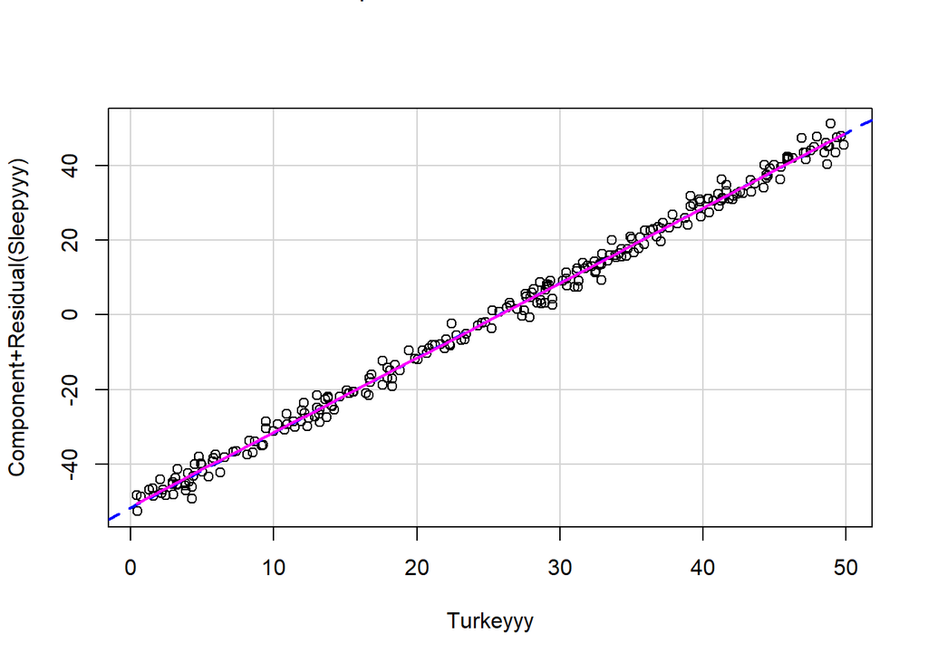

```r
# Evaluate Nonlinearity
# component + residual plot aka partial-residual plots
crPlots(Gobble.model.2)
```

## 5.6 Prueba del supuesto de independencia: durbinWatsonTest()

El Durbin Watson examina si los errores están autocorrelacionados consigo mismos. El nulo indica que no están autocorrelacionados (lo que queremos). Esta prueba podría resultar especialmente útil cuando se realiza una regresión múltiple (series temporales). Por ejemplo, esta prueba podría indicarle si los residuos en el momento 1 están correlacionados con los residuos en el momento 2 (no deberían estarlo). En otras palabras, esta prueba es útil para verificar que no hemos violado el supuesto de independencia .

```r
durbinWatsonTest(Gobble.model.2)
```

```
##  lag Autocorrelation D-W Statistic p-value
##    1     -0.03984474      2.079617   0.538
##  Alternative hypothesis: rho != 0
```

¿Como lo hicimos? p > 0,05, por lo que los errores no están autocorrelacionados. No hemos violado el supuesto de independencia. ¡Hurra!

## 5.7 Prueba global de supuestos del modelo: gvlma()

Finalmente, si le da pereza, siempre puede realizar una prueba global de los supuestos del modelo utilizando el paquete gvlma. ¡Mira (casi) todo usando un solo paquete! Tal como sugirieron las otras tramas, todas nuestras suposiciones parecen aceptables. Nota especial : no hay muchos aportes de la comunidad de usuarios de R sobre cada una de estas decisiones y qué significa exactamente cada decisión. ¡Cuidado usuario!

```r
library(gvlma)
gvmodel.gobble <- gvlma(Gobble.model.2)
summary(gvmodel.gobble)
```

```
##
## Call:
## lm(formula = Sleepyyy ~ Turkeyyy, data = dataset.gobble2)
##
## Residuals:
##     Min      1Q  Median      3Q     Max
## -6.2833 -1.4101  0.2003  1.3977  5.1238
##
## Coefficients:
##             Estimate Std. Error t value Pr(>|t|)
## (Intercept) 1.289839   0.265924    4.85 2.18e-06 ***
## Turkeyyy    2.005301   0.009012  222.50  < 2e-16 ***
## ---
## Signif. codes:  0 '***' 0.001 '**' 0.01 '*' 0.05 '.' 0.1 ' ' 1
##
## Residual standard error: 2.056 on 248 degrees of freedom
## Multiple R-squared:  0.995,  Adjusted R-squared:  0.995
## F-statistic: 4.951e+04 on 1 and 248 DF,  p-value: < 2.2e-16
##
##
## ASSESSMENT OF THE LINEAR MODEL ASSUMPTIONS
## USING THE GLOBAL TEST ON 4 DEGREES-OF-FREEDOM:
## Level of Significance =  0.05
##
## Call:
##  gvlma(x = Gobble.model.2)
##
##                      Value p-value                Decision
## Global Stat        3.05652  0.5484 Assumptions acceptable.
## Skewness           0.62165  0.4304 Assumptions acceptable.
## Kurtosis           0.03853  0.8444 Assumptions acceptable.
## Link Function      0.64649  0.4214 Assumptions acceptable.
## Heteroscedasticity 1.74985  0.1859 Assumptions acceptable.
```

# 6 ¿Qué tal un ejemplo más problemático?

Hagamos intencionalmente que la relación entre el consumo de pavo y la hora de la siesta sea positivamente cuadrática.

```r
#set the seed. This ensures that rnorm will sample the same datapoints for you as it did for me.
set.seed(66)

 N <- 250
    TurkeyTime2 <- runif(N, 0, 50)
    NapTime2 <- (TurkeyTime2^2 + rnorm(N, sd=16)) + 500
    #I made nap time have a positive quadratic relationship with turkey so this example would be icky.
    #I also added 500 to the equation to ensure we don't get a negative intercept for nap time.

#Let's make a data frame
dataset.gobble3<-data.frame(
  Turkeyyy2 = TurkeyTime2,
  Sleepyyy2 = NapTime2)


#Let's make things really interesting by adding some bad outliers to the data!
outliers<-data.frame(Turkeyyy2=c(45, 50), Sleepyyy2=c(3000,4000))
dataset.gobble3<-rbind(outliers, dataset.gobble3)
#binds 2 new outliers to the top of our dataset

str(dataset.gobble3)
```

```
## 'data.frame':    252 obs. of  2 variables:
##  $ Turkeyyy2: num  45 50 49.5 41.5 29.3 ...
##  $ Sleepyyy2: num  3000 4000 2933 2213 1363 ...
```

```r
#note that our 2 outliers are at the top of the dataset now
head(dataset.gobble3)
```

|  | Turkeyyy2 | Sleepyyy2 |
| --- | --- | --- |
| 1 | 45.00000 | 3000.0000 |
| 2 | 50.00000 | 4000.0000 |
| 3 | 49.49683 | 2933.0027 |
| 4 | 41.48463 | 2213.3863 |
| 5 | 29.29435 | 1362.8240 |
| 6 | 20.85231 | 941.4564 |

Probemos nuestro nuevo modelo ridículo (fíjate cuánto tiempo duerme la gente ahora…)

```r
#use lm() function here to run your regression model
Gobble.model.3<-lm(Sleepyyy2~Turkeyyy2, data=dataset.gobble3)
summary(Gobble.model.3)
```

```
##
## Call:
## lm(formula = Sleepyyy2 ~ Turkeyyy2, data = dataset.gobble3)
##
## Residuals:
##     Min      1Q  Median      3Q     Max
## -231.21 -162.12  -57.55  119.92 1368.81
##
## Coefficients:
##             Estimate Std. Error t value Pr(>|t|)
## (Intercept)  14.6311    26.3289   0.556    0.579
## Turkeyyy2    52.3313     0.9236  56.658   <2e-16 ***
## ---
## Signif. codes:  0 '***' 0.001 '**' 0.01 '*' 0.05 '.' 0.1 ' ' 1
##
## Residual standard error: 202.1 on 250 degrees of freedom
## Multiple R-squared:  0.9277, Adjusted R-squared:  0.9275
## F-statistic:  3210 on 1 and 250 DF,  p-value: < 2.2e-16
```

```r
#Stargazer package gave us a pretty summary table, right?!
#Note that it outputs a measure of effect size for the model (i.e., adjusted R-squared)
library(stargazer)
stargazer(Gobble.model.3,type="text", ci = T)
```

```
##
## ===============================================
##                         Dependent variable:
##                     ---------------------------
##                              Sleepyyy2
## -----------------------------------------------
## Turkeyyy2                    52.331***
##                          (50.521, 54.142)
##
## Constant                      14.631
##                          (-36.972, 66.235)
##
## -----------------------------------------------
## Observations                    252
## R2                             0.928
## Adjusted R2                    0.927
## Residual Std. Error     202.078 (df = 250)
## F Statistic         3,210.114*** (df = 1; 250)
## ===============================================
## Note:               *p<0.1; **p<0.05; ***p<0.01
```

Con nuestro nuevo modelo, parece que un mayor consumo de pavo todavía predice un mayor tiempo de siesta. ¿Pero se cumplen nuestras suposiciones?

Primero visualicemos esta relación para obtener una comprensión intuitiva de los datos.

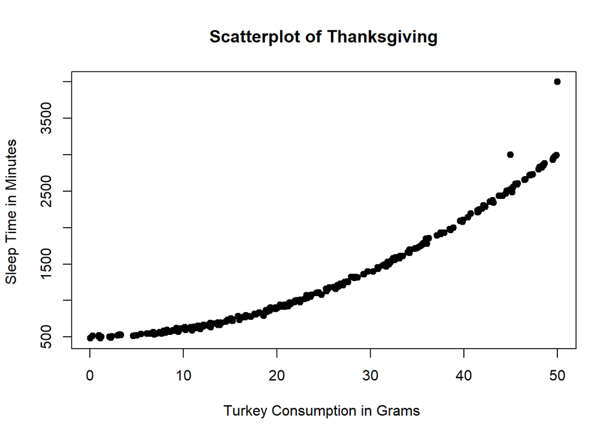

```r
plot(dataset.gobble3, main="Scatterplot of Thanksgiving",
    xlab="Turkey Consumption in Grams ", ylab="Sleep Time in Minutes ", pch=19)
```

Seguro que no parece lineal y podemos ver nuestros valores atípicos. Pero ¿qué pasa con los otros supuestos?

## 6.1 Obtener una instantánea amplia: plot()

Ejecutemos la función plot() para obtener una instantánea de cuántas de nuestras suposiciones están funcionando.

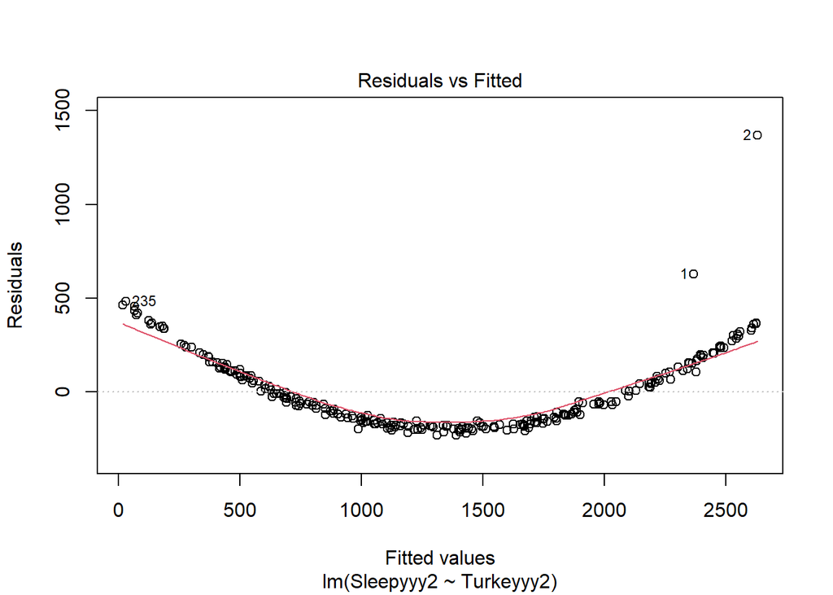

```r
#Let's go through each plot one by one.
plot(Gobble.model.3,which=1)
```

Trama uno : ¿Son los datos lineales? No; los residuos no deben agruparse en forma de sonrisa. Deben estar esparcidos aleatoriamente a lo largo de la trama y la línea roja debe ser horizontal/no curvada. ¿Son los datos homocedásticos? No parece serlo, porque los residuos no están distribuidos equitativamente alrededor de la recta y = 0. Hasta ahora, parece que hemos violado los supuestos de linealidad y homocedasticidad.

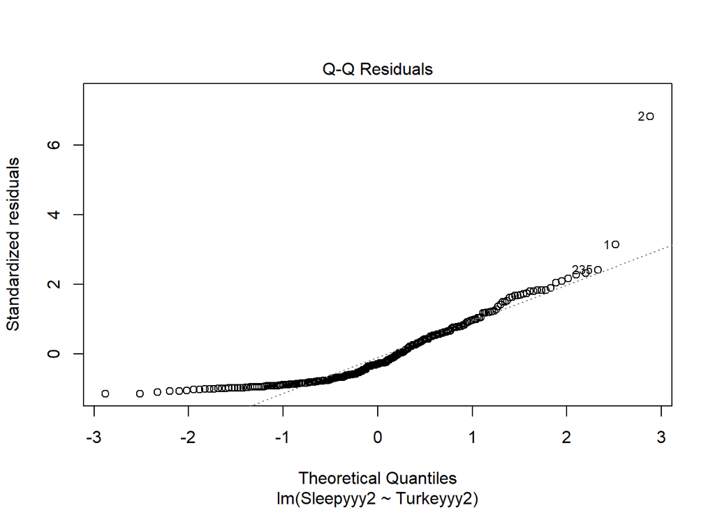

```r
#Let's look at our second plot.
plot(Gobble.model.3,which=2)
```

Trama dos : ¿Cómo nos va con el supuesto de normalidad? No es bueno; el QQplot es curvo en los extremos en lugar de recto a lo largo de la línea de puntos del ángulo de 45 grados. Esto sugiere que hemos violado el supuesto de normalidad.

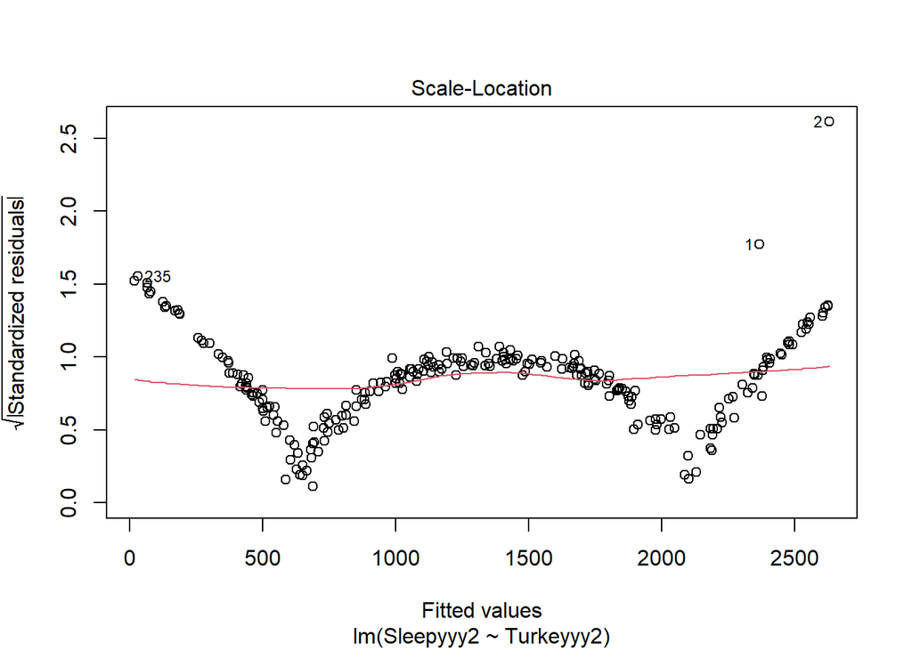

```r
#Let's look at our third plot.
plot(Gobble.model.3,which=3)
```

Trama tres : ¿Son nuestros datos homocedásticos? Éste es complicado; la línea roja es bastante horizontal, lo que sugiere que los datos son, de hecho, homocedásticos. Sin embargo, observe cómo nuestros residuos están agrupados en forma de W en lugar de verse distribuidos aleatoriamente como el cielo nocturno. Esto no es bueno: sugiere que hay mucha variación en la dispersión residual alrededor de la línea de mejor ajuste. En otras palabras, se ha violado el supuesto de homocedasticidad.

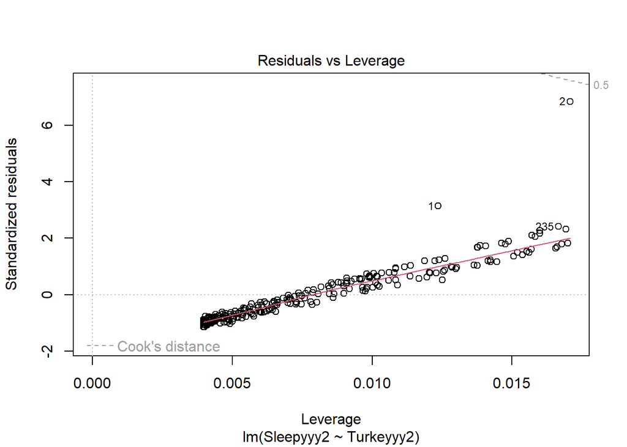

```r
#Let's go through each plot one by one.
plot(Gobble.model.3,which=5)
```

Trama cuatro : ¿Tenemos casos influyentes? La observación 2 está muy cerca de cruzar la línea de puntos de la distancia de Cook (es decir, la distancia de Cook para la observación 2 es casi > 0,5), pero en realidad no la cruza. Estrictamente hablando, esta trama sugiere que nuestros valores atípicos no son influyentes.

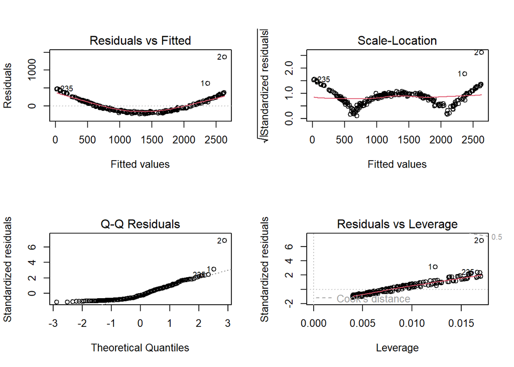

```r
#Or, if you'd like to see all 4 plots side by side, try this:
layout(matrix(c(1,2,3,4),2,2))
plot(Gobble.model.3)
```

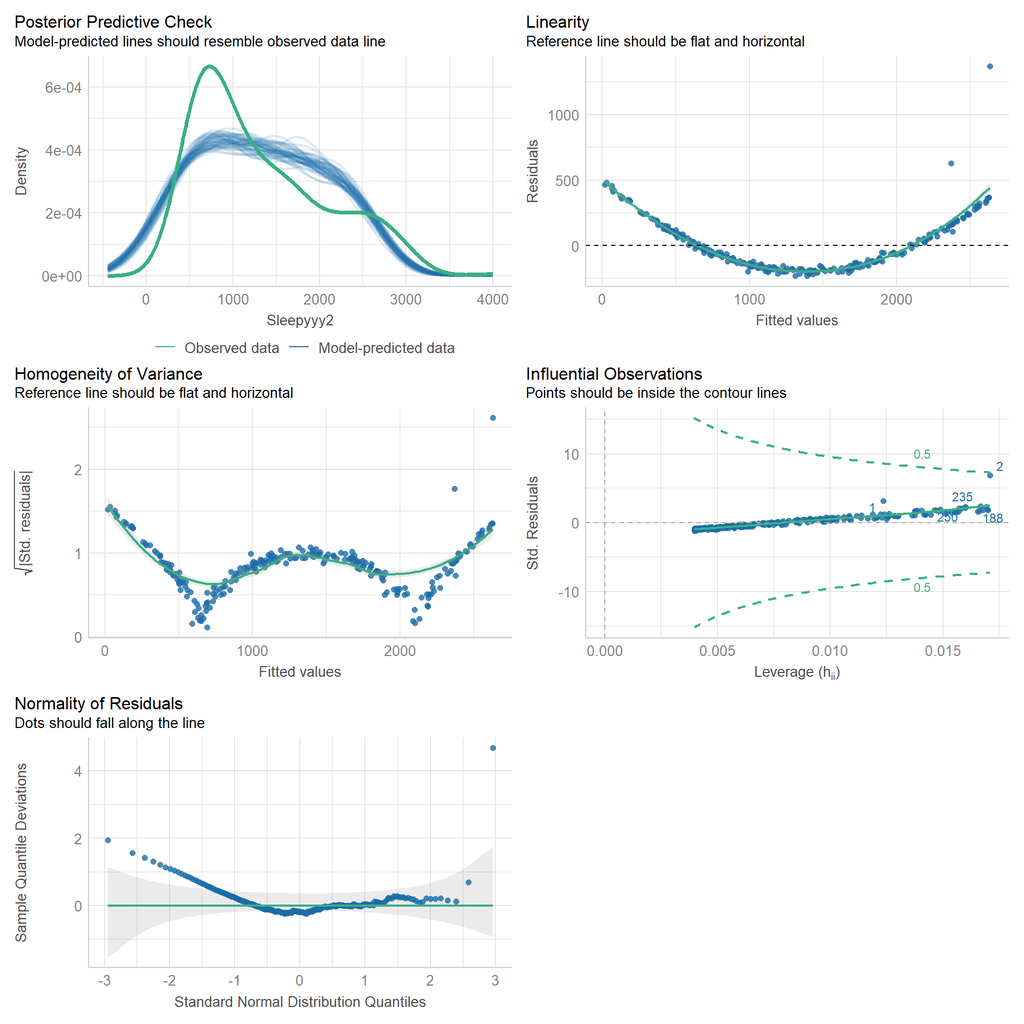

```r
check_model(Gobble.model.3)
```

Evaluación general : no sorprende que se viole el supuesto de linealidad en este ejemplo (visible en el gráfico 1). Además, el gráfico 2 sugiere que se viola el supuesto de normalidad, y los gráficos 1 y 3 sugieren que se viola el supuesto de homocedasticidad. Las observaciones 1, 2 y 235 son valores atípicos (pero no influyen, como se revela en el gráfico 4): están marcadas como valores atípicos en cada uno de los gráficos anteriores. Verifique si hay algo extraño en estos temas o si hubo errores en el ingreso de datos. En resumen, ¡nuestro modelo es un desastre!

```r
# Assessing Outliers
#Are there outliers? Yes,
summary(influence.measures(Gobble.model.3))
```

```
## Potentially influential observations of
##   lm(formula = Sleepyyy2 ~ Turkeyyy2, data = dataset.gobble3) :
##
##     dfb.1_ dfb.Trk2 dffit   cov.r   cook.d hat
## 1   -0.16   0.29     0.36_*  0.94_*  0.06   0.01
## 2   -0.53   0.87     1.00_*  0.68_*  0.41   0.02
## 141  0.28  -0.24     0.28_*  0.99    0.04   0.02
## 188  0.31  -0.27     0.31_*  0.98    0.05   0.02
## 235  0.32  -0.28     0.32_*  0.98    0.05   0.02
## 250  0.29  -0.25     0.29_*  0.98    0.04   0.02
```

### 6.2.1 Pruebas de observaciones influyentes: distancia de Cook

Revisemos la distancia de Cook: debería marcar las mismas observaciones que en el gráfico 4 en la función plot().

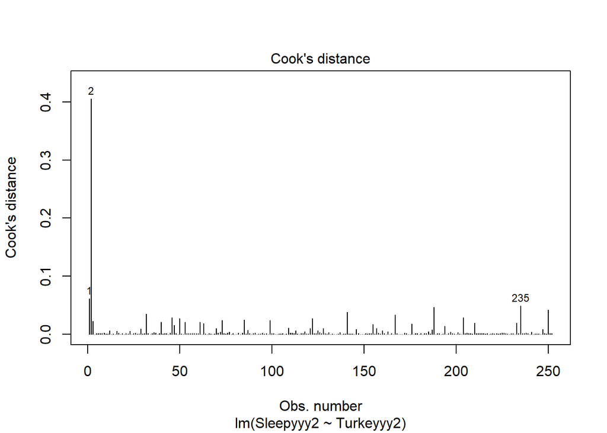

```r
# Influential Observations
# Cook's D plot
# identify D values > 4/(n-k-1)
cutoff <- 4/((nrow(dataset.gobble3)-length(Gobble.model.3$coefficients)-2))
plot(Gobble.model.3, which=4, cook.levels=cutoff)
```

¿Como lo hicimos? Las observaciones 1, 2 y 235 parecen ser las más influyentes en nuestros datos, las mismas que se señalan en el gráfico de residuos versus apalancamiento anterior. Sin embargo, tenga en cuenta que el gráfico de residuos frente a apalancamiento anterior (gráfico 4) sugiere que estas observaciones no influyen realmente en los resultados de nuestra regresión.

## 6.3 Prueba del supuesto de normalidad: studres()

¿Están nuestros residuos distribuidos normalmente?

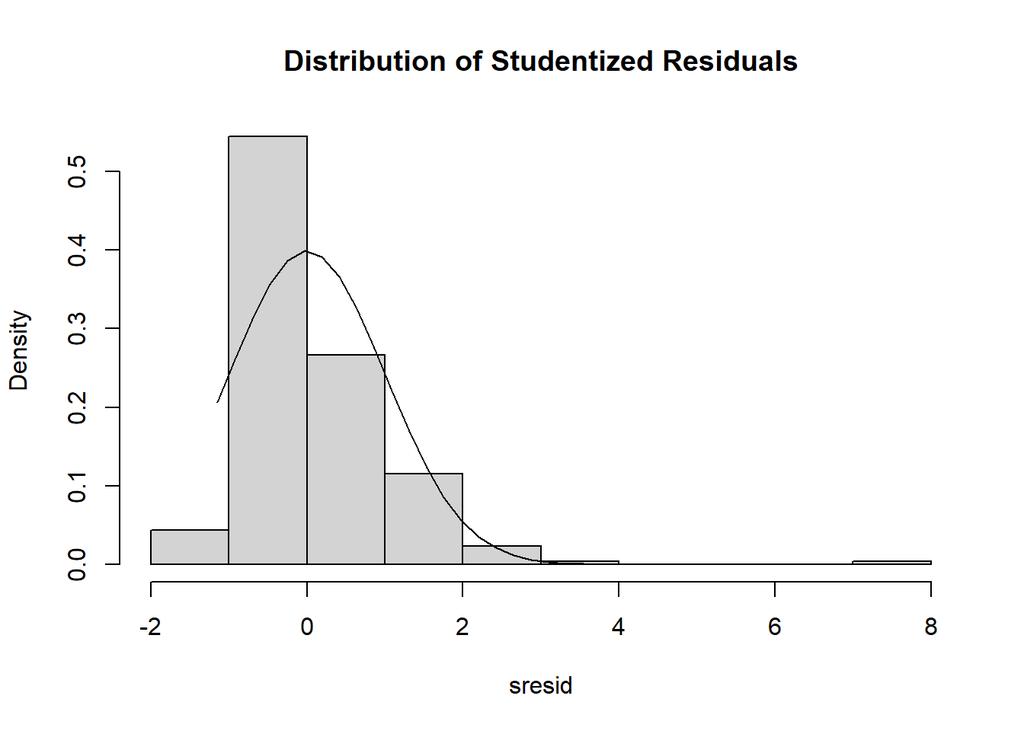

```r
# distribution of studentized residuals
sresid <- studres(Gobble.model.3)
hist(sresid, freq=FALSE,
     main="Distribution of Studentized Residuals")
xfit<-seq(min(sresid),max(sresid),length=40)
yfit<-dnorm(xfit)
lines(xfit, yfit)
```

¡No! No sorprendido; ¡Nuestro modelo es intencionalmente horrible!

## 6.4 Prueba del supuesto de homocedasticidad: ncvTest()

¿Somos homocedásticos? Recuerde: el valor nulo aquí indica que hay una variación constante.

```r
# Evaluate homoscedasticity
# non-constant error variance test
ncvTest(Gobble.model.3)
```

```
## Non-constant Variance Score Test
## Variance formula: ~ fitted.values
## Chisquare = 9.740168, Df = 1, p = 0.0018028
```

Hemos violado el supuesto de homocedasticidad (p < 0,05), y esta conclusión se ve reforzada por lo que vimos en los gráficos 1 y 3 anteriores.

## 6.5 Prueba del supuesto de linealidad: crPlots()

¿Nuestro predictor tiene una relación lineal con la variable dependiente?

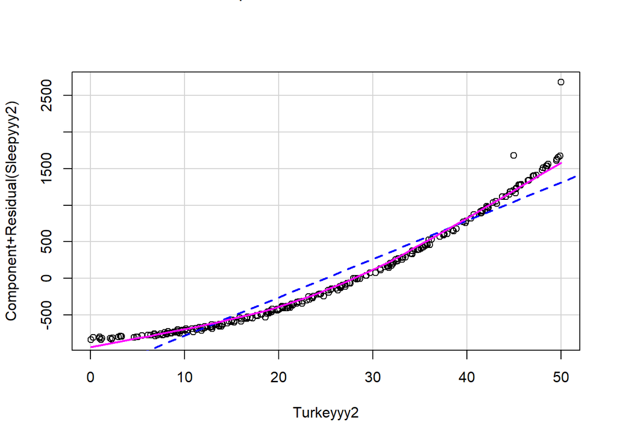

```r
# Evaluate Nonlinearity
# component + residual plot aka partial-residual plots
crPlots(Gobble.model.3)
```

No, nuestro modelo no parece lineal. Parece una relación cuadrática.

## 6.6 Prueba del supuesto de independencia: durbinWatsonTest()

¿Independencia de errores? El nulo indica que no están autocorrelacionados (lo que queremos).

```r
durbinWatsonTest(Gobble.model.3)
```

```
##  lag Autocorrelation D-W Statistic p-value
##    1        0.116833      1.723796   0.028
##  Alternative hypothesis: rho != 0
```

Hemos violado el supuesto de independencia (p < 0,05).

## 6.7 Prueba global de supuestos del modelo: gvlma()

¡Finalmente, veamos qué dice el paquete gvlma!

```r
gvmodel.gobble3 <- gvlma(Gobble.model.3)
summary(gvmodel.gobble3)
```

```
##
## Call:
## lm(formula = Sleepyyy2 ~ Turkeyyy2, data = dataset.gobble3)
##
## Residuals:
##     Min      1Q  Median      3Q     Max
## -231.21 -162.12  -57.55  119.92 1368.81
##
## Coefficients:
##             Estimate Std. Error t value Pr(>|t|)
## (Intercept)  14.6311    26.3289   0.556    0.579
## Turkeyyy2    52.3313     0.9236  56.658   <2e-16 ***
## ---
## Signif. codes:  0 '***' 0.001 '**' 0.01 '*' 0.05 '.' 0.1 ' ' 1
##
## Residual standard error: 202.1 on 250 degrees of freedom
## Multiple R-squared:  0.9277, Adjusted R-squared:  0.9275
## F-statistic:  3210 on 1 and 250 DF,  p-value: < 2.2e-16
##
##
## ASSESSMENT OF THE LINEAR MODEL ASSUMPTIONS
## USING THE GLOBAL TEST ON 4 DEGREES-OF-FREEDOM:
## Level of Significance =  0.05
##
## Call:
##  gvlma(x = Gobble.model.3)
##
##                     Value   p-value                   Decision
## Global Stat        954.53 0.000e+00 Assumptions NOT satisfied!
## Skewness           141.28 0.000e+00 Assumptions NOT satisfied!
## Kurtosis           574.88 0.000e+00 Assumptions NOT satisfied!
## Link Function      222.03 0.000e+00 Assumptions NOT satisfied!
## Heteroscedasticity  16.35 5.265e-05 Assumptions NOT satisfied!
```

Esto confirma lo que vimos arriba. ¡Tenemos grandes problemas con todas las suposiciones! Nota especial : no hay muchos aportes de la comunidad de usuarios de R sobre cada una de estas decisiones y qué significa exactamente cada decisión. ¡Cuidado usuario!

# 7 Introducción a la regresión múltiple

Repasemos un ejemplo muy básico para presentarle la regresión múltiple en R.

Creemos un marco de datos que combine nuestras variables de consumo de pavo, consumo de vino y tiempo de sueño.

```r
#set the seed. This ensures that rnorm will sample the same datapoints for you as it did for me.
set.seed(99)

N <- 250
    TurkeyYum <- runif(N, 0, 50)
    WineYum <- runif(N, 0, 50)
    NapYum <- 2*TurkeyYum + rnorm(N, sd=0.5)

#ID number
IDMultiple<-factor(c(seq(1:N)))

### Let's put it all together
dataset.gobble.multiple<-data.frame(
  subjectIDmultiple = IDMultiple,
  TurkeyYummy = TurkeyYum,
  WineYummy = WineYum,
  SleepyYummy = NapYum)

str(dataset.gobble.multiple)
```

```
## 'data.frame':    250 obs. of  4 variables:
##  $ subjectIDmultiple: Factor w/ 250 levels "1","2","3","4",..: 1 2 3 4 5 6 7 8 9 10 ...
##  $ TurkeyYummy      : num  29.24 5.69 34.21 49.63 26.75 ...
##  $ WineYummy        : num  39.32 2.76 26.25 33.23 46.04 ...
##  $ SleepyYummy      : num  58.3 11.3 68 99.4 54.1 ...
```

```r
head(dataset.gobble.multiple)
```

|  | subjectIDmultiple | TurkeyYummy | WineYummy | SleepyYummy |
| --- | --- | --- | --- | --- |
| 1 | 1 | 29.235593 | 39.319754 | 58.33437 |
| 2 | 2 | 5.689084 | 2.757302 | 11.32146 |
| 3 | 3 | 34.213237 | 26.246075 | 67.97108 |
| 4 | 4 | 49.625439 | 33.232598 | 99.43534 |
| 5 | 5 | 26.749679 | 46.043982 | 54.06836 |
| 6 | 6 | 48.330703 | 7.676541 | 97.07028 |

Ahora ejecutemos un modelo de regresión múltiple (definido como un modelo de regresión con 2 o más predictores) que considere si el consumo de pavo Y el consumo de vino predicen el tiempo de sueño. Lo que notará en el modelo a continuación es que generalmente toma la misma forma que la regresión lineal simple: “Nombra tu modelo” <- lm(Criterio~Predictor1 + Predictor2, datos=“nombre de tu conjunto de datos”). Ahora, sin embargo, tengo 2 predictores y hay un signo + entre ellos. Lo que esto significa es que los predictores se ingresan simultáneamente en el modelo y el resultado refleja el efecto de cada uno sobre el criterio, controlando el otro.

```r
Gobble.model.multiple<-lm(SleepyYummy~TurkeyYummy+WineYummy, data=dataset.gobble.multiple)
summary(Gobble.model.multiple)
```

```
##
## Call:
## lm(formula = SleepyYummy ~ TurkeyYummy + WineYummy, data = dataset.gobble.multiple)
##
## Residuals:
##     Min      1Q  Median      3Q     Max
## -1.5216 -0.3478 -0.0511  0.3764  1.2531
##
## Coefficients:
##               Estimate Std. Error t value Pr(>|t|)
## (Intercept) -0.0028384  0.0856371  -0.033    0.974
## TurkeyYummy  2.0003258  0.0023184 862.815   <2e-16 ***
## WineYummy   -0.0004085  0.0021686  -0.188    0.851
## ---
## Signif. codes:  0 '***' 0.001 '**' 0.01 '*' 0.05 '.' 0.1 ' ' 1
##
## Residual standard error: 0.5164 on 247 degrees of freedom
## Multiple R-squared:  0.9997, Adjusted R-squared:  0.9997
## F-statistic: 3.723e+05 on 2 and 247 DF,  p-value: < 2.2e-16
```

¿Qué quiere decir esto? Significa que el pavo es un predictor importante del tiempo de sueño, controlando el consumo de vino: cuanto más pavo se consume, más largas son las siestas. Sin embargo, el vino no es un predictor significativo del tiempo de sueño después de controlar el consumo de pavo; no están relacionados.

## 7.1 Supuestos

Se evaluan los mismos supuestos que la regresión lineal simple.

### 7.1.1 Evaluación rápida de supuestos

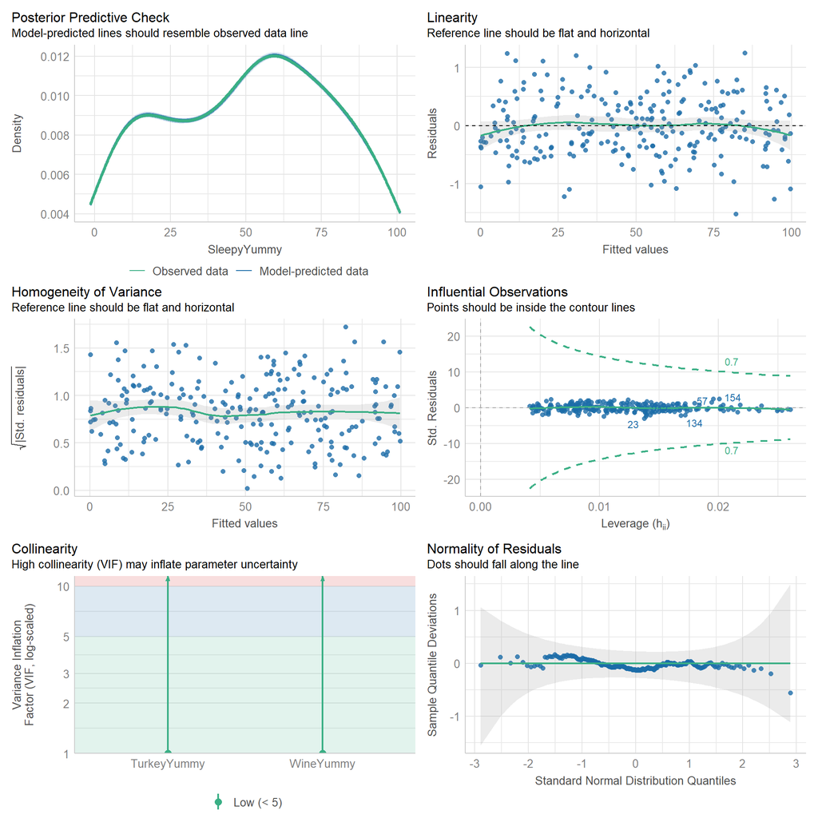

```r
# o con la libreria performance
library(performance)

check_model(Gobble.model.multiple)
```

Sin embargo, tambien se debe evaluar la Multicolinealidad

### 7.1.2 Multicolinealidad

¿Qué es la multicolinealidad? Cuando dos variables predictoras están muy correlacionadas entre sí decimos que existe colinealidad. Cuando son tres o más las variables involucradas, la llamamos multi-colinealidad, esto significa que hay redundancia entre las variables predictoras.

¿Qué pasa si no se cumple este supuesto? La multicolinealidad reduce la precisión de los coeficientes estimados, lo que debilita la potencia estadística de nuestro modelo de regresión y dificulta identificar la significación e importancia de los predictores. Si deseas más información específica, puedes leer este post.

¿Cómo comprobarlo? Para un predictor dado, la multicolinealidad puede evaluarse mediante el cálculo del factor de inflación de varianza (Variance Inflation Factor, V IF)34 que mide cuánto se infla la varianza (variación) de un coeficiente de regresión debido a la multicolinealidad en el modelo. O dicho de otro modo, indica si un predictor tiene una fuerte relación lineal con otros predictores. El valor más pequeño posible de VIF es uno (que indica ausencia de multicolinealidad), pero el valor del VIF no tiene un límite superior. Para determinar qué valor del V IF debería ser preocupante no existen reglas estrictas, pero algunos autores han sugerido que el VIF no supere ciertos valores. Myers (1990) sugiere que un valor mayor a 10 es preocupante, mientras que James et al. 2014 sugieren que es recomendable que no se exceda de 5.

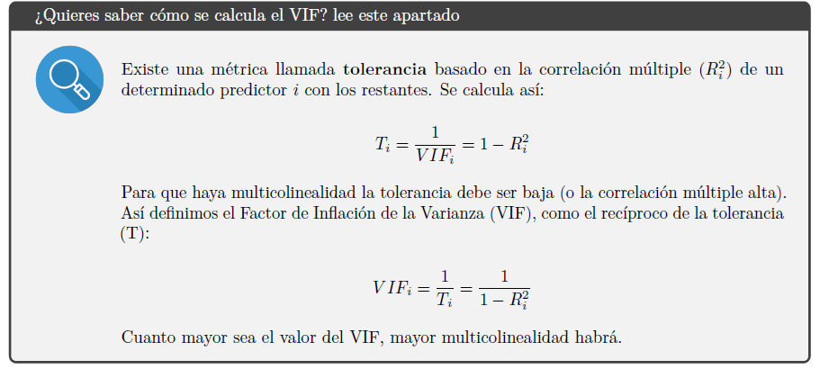

¿Cómo puedes mejorar el modelo? Si eliminamos de nuestro modelo las variables con problema de multi-colinealidad, obtendremos un modelo más simple sin comprometer la precisión del modelo, lo cual es bueno. También puedes realizar un análisis de componentes principales (PCA) para crear una combinación de variables explicativas independientes antes de realizar el modelo RLM, o utilizar el método de mínimos cuadrados parciales (PLS) para realizar la regresión.

```r
# Solo fijate en el estimado puntual no en el IC95%
check_collinearity(Gobble.model.multiple)
```

| Term | VIF | VIF_CI_low | VIF_CI_high | SE_factor | Tolerance | Tolerance_CI_low | Tolerance_CI_high |
| --- | --- | --- | --- | --- | --- | --- | --- |
| TurkeyYummy | 1.000109 | 1 | Inf | 1.000055 | 0.9998909 | 0 | 1 |
| WineYummy | 1.000109 | 1 | Inf | 1.000055 | 0.9998909 | 0 | 1 |

# 8 REFERENCIAS

Revisar: https://ademos.people.uic.edu/Chapter12.html#

The following websites were very helpful to me while writing this chapter.

http://sphweb.bumc.bu.edu/otlt/MPH-Modules/BS/R/R5_Correlation-Regression/R5_Correlation-Regression7.html (author: Boston University School of Public Health)

http://www.vikparuchuri.com/blog/r-regression-diagnostics-part-1/ (author: Vik Paruchuri)

http://data.library.virginia.edu/diagnostic-plots/ (author: Bommae Kim, University of Virginia)

Other useful online tutorials: https://ww2.coastal.edu/kingw/statistics/R-tutorials/simplelinear.html http://www.statmethods.net/stats/regression.html http://tutorials.iq.harvard.edu/R/Rstatistics/Rstatistics.html http://www.statmethods.net/stats/rdiagnostics.html

Brush up on your regression diagnositics options: https://cran.r-project.org/web/packages/car/vignettes/embedding.pdf